# R Notebook

# Chapter 13 Probability

Regarding chance, probability has a very intuitive definition. Today probability theory is being used much more broadly with the word *probability* commonly used in everyday language. Probability continues to be highly useful in modern games of chance.

## 13.1 Discrete probability

categorical data > subset of probability is *discrete probability*.

### 13.1.1 Relative frequency

probability of an event is as the proportion of times the event occurs, when we repeat the experiment an infinite number of times, independently, and under the same conditions.

### 13.1.2 Notation

We use the notation **Pr(a)** to denote the probability of event **A** happening.

event: things that can happen when something occurs by chance.

For continuous variables, we write event in a more mathematical form: X>=6.

### 13.1.3 Probability distributions

We simply assign a probability to each category.

## 13.2 Monte Carlo simulations for categorical data

pick a bead at random from a bag that contains three blue beads and two red ones.

‘sample’ function in R. we use the function ‘rep’ to generate the urn:

```r
beads <- rep(c("red", "blue"), times = c(2,3))
beads
```

```
[1] "red"  "red"  "blue" "blue" "blue"
```

```r
sample(beads,1)
```

```
[1] "blue"
```

This line of code produces one random outcome We repeate the experiment a large enough number of times to make the results equivalent to repeating forever.

function ‘replicate’ : permits us to repeat same task any number of times:

```r
B <- 10000
events <- replicate(B, sample(beads, 1))
```

```r
tab <- table(events)
tab
```

```
events
blue  red
5952 4048
```

```r
prop.table(tab)
```

```
events
  blue    red
0.5952 0.4048
```

statistical theory: as B gets larger, the estimates get closer to 3/5=.6 and 2/5=.4.

### 13.2.1 Setting the random seed

```r
set.seed(1986)
```

We used random number generators. Many of the results can actually change by chance ; if you want to ensure that results are exactly the same every time, you can set R’s random number generation seed to a specific number. Above we set it to 1986: A popular way to pick the seed is the year-month-day. We want to avoid using the same seed everytime.

```r
?set.seed
```

### 13.2.2 With and without replacement

function ‘sample’ has argument that allows us to pick more than one element. However, default is *Without replacement*

```r
sample(beads, 5)
```

```
[1] "red"  "blue" "blue" "blue" "red"
```

```r
sample(beads, 5)
```

```
[1] "red"  "red"  "blue" "blue" "blue"
```

```r
sample(beads, 5)
```

```
[1] "blue" "red"  "blue" "red"  "blue"
```

results in rearrangements that always have three blue and two red beads. if we ask ‘six beads selected’ : error

```r
sample(beads,6)
```

```
Error in sample.int(length(x), size, replace, prob) :
  cannot take a sample larger than the population when 'replace = FALSE'
```

we can use ‘replace’ argument, which defaults to FALSE, to replace=TRUE

```r
events <- sample(beads, B, replace = TRUE)
prop.table(table(events))
```

```
events
  blue    red
0.5957 0.4043
```

## 13.3 Independence

If the outcome of one does not affect the other, we say two events are independent : coin tosses, picking beads

Not independent; card games, picking beads without replacement

```r
x <- sample(beads, 5)
```

```r
x[2:5]
```

```
[1] "red"  "blue" "red"  "blue"
```

Now you know that the probability of **BLUE** is 1 since the only bead left is **BLUE**. The events are not independent, so the probabilities change.

## 13.4 Conditional probabilities

When events are not independent, *conditional probabilities* are useful. We use | as shorting for ‘given that’ or ‘conditional on’ When two events are independent, Pr(A|B)=Pr(A) : The fact that B happened doesn’t affect the probability of A happening

## 13.5 Addition and Multiplication Rules

### 13.5.1 Multipication Rule

Pr(A and B) = Pr(A)Pr(B|A)

Blackjack ; two random cards. the goal is to get closer to 21 than the dealer, without going over. Face cards are worth 10 points and aces are worth 11 or 1 (you choose) To calculate the chances of getting a 21 by drawing an Ace and then a face card, we compute the probability of the first being an Ace and multiply by the probability of drawing a face card or a 10 given that the first was an Ace: 1/13 X 16/51, which is about 0.025

Pr(A and B and C) = Pr(A)Pr(B|A)Pr(C|A and B)

### 13.5.2 Multiplication rule under independence

For independent events,

Pr(A and B and C) = Pr(A)Pr(B)Pr(C)

We have to be very careful in assuming independence!

Pr(B|A) = Pr(A and B) / Pr(A)

### 13.5.3 Addition Rule

Pr(A or B) = Pr(A) + Pr(B) - Pr(A and B)

## 13.6 Combinations and permutations

To compute the probability distribution of one draw, we simply listed out all the possibilities.

What is the probability that if I draw five cards without replacement, I get all cards of the same suit, what is known as a “flush” in poker?

function ‘expand.grid’ and ‘paste’ : ‘paste’ to create strings by joining smaller strings.

```r
number <- "Three"
suit <- "Hearts"
paste(number, suit)
```

```
[1] "Three Hearts"
```

‘paste’ can also work on pair of vectors performing the operation element-wise

```r
paste(letters[1:5], as.character(1:5))
```

```
[1] "a 1" "b 2" "c 3" "d 4" "e 5"
```

‘expand.grid’ gives us all the combinations of entries of two vectors

```r
expand.grid(pants = c("blue", "black"), shirt = c("white", "grey", "plaid"))
```

| pants | shirt |
| --- | --- |
| blue | white |
| black | white |
| blue | grey |
| black | grey |
| blue | plaid |
| black | plaid |

for deck of cards,

```r
suits <- c("Diamonds", "Clubs", "Hearts", "Spades")
numbers <- c("Ace", "Deuce", "Three", "Four", "Five", "Six", "Seven",
             "Eight", "Nine", "Ten", "Jack", "Queen", "King")
deck <- expand.grid(number=numbers, suit=suits)
deck <- paste(deck$number, deck$suit)
```

We can doublecheck probability of king in the first card = 1/13 by computing proportion

```r
kings <- paste("King", suits)
mean(deck %in% kings)
```

```
[1] 0.07692308
```

How about the conditional probability of the second card being a King given that the first was a King?

we use function ‘permutations’ from ‘gtools’ package. For any list of size n, this function computes all the different combinations we can get when we select r items.

All the ways we can choose 2 numbers from list ‘1, 2, 3’

```r
install.packages("gtools")
library(gtools)
permutations(3, 2)
```

```
     [,1] [,2]
[1,]    1    2
[2,]    1    3
[3,]    2    1
[4,]    2    3
[5,]    3    1
[6,]    3    2
```

Order matters here!

We can add a vector.

random seven digit phone numbers out of all possible phone numbers (without repeats)

```r
all_phone_numbers <- permutations(10, 7, v = 0:9)
n <- nrow(all_phone_numbers)
index <- sample(n, 5)
all_phone_numbers[index,]
```

```
     [,1] [,2] [,3] [,4] [,5] [,6] [,7]
[1,]    9    1    2    0    3    5    8
[2,]    1    0    7    5    6    9    3
[3,]    6    3    7    1    5    4    9
[4,]    0    2    7    9    3    4    5
[5,]    4    0    7    6    8    9    3
```

instead of using the numbers 1~10(default) it uses what we provided through v : 0~9

all possible ways we can choose two cards when the order matters, we type:

```r
hands <- permutations(52, 2, v = deck)
```

```r
hands
```

```
        [,1]             [,2]
   [1,] "Ace Clubs"      "Ace Diamonds"
   [2,] "Ace Clubs"      "Ace Hearts"
   [3,] "Ace Clubs"      "Ace Spades"
   [4,] "Ace Clubs"      "Deuce Clubs"
   [5,] "Ace Clubs"      "Deuce Diamonds"
   [6,] "Ace Clubs"      "Deuce Hearts"
   [7,] "Ace Clubs"      "Deuce Spades"
   [8,] "Ace Clubs"      "Eight Clubs"
   [9,] "Ace Clubs"      "Eight Diamonds"
  [10,] "Ace Clubs"      "Eight Hearts"
  [11,] "Ace Clubs"      "Eight Spades"
  [12,] "Ace Clubs"      "Five Clubs"
  [13,] "Ace Clubs"      "Five Diamonds"
  [14,] "Ace Clubs"      "Five Hearts"
```

[output cut: 487 more lines]

```r
first_card <- hands[,1]
second_card <- hands[,2]
```

now the cases for which the first hand was a king:

```r
kings <- paste("King", suits)
sum(first_card %in% kings)
```

```
[1] 204
```

To get the conditional probability, we compute what fraction of these have a King in the second card:

```r
sum(first_card%in%kings & second_card%in%kings) / sum(first_card%in%kings)
```

```
[1] 0.05882353
```

The code above is equivalent to

```r
mean(first_card%in%kings & second_card%in%kings) / mean(first_card%in%kings)
```

```
[1] 0.05882353
```

In Blackjack if you get an Ace and a face card in the first draw, it is called a Natural 21 and you win automatically. If we wanted to compute the probability of this happening, we would enumerate the combinations, not the permutations, since the order does not matter.

```r
combinations(3,2)
```

```
     [,1] [,2]
[1,]    1    2
[2,]    1    3
[3,]    2    3
```

to compute the probability of a Natural 21 in Blackjack

```r
aces <- paste("Ace", suits)

facecard <- c("King", "Queen", "Jack", "Ten")
facecard <- expand.grid(number = facecard, suit = suits)
facecard <- paste(facecard$number, facecard$suit)

hands <- combinations(52, 2, v = deck)
mean(hands[,1] %in% aces & hands[,2] %in% facecard)
```

```
[1] 0.04826546
```

```r
?|
```

```
Error: unexpected '|' in "?|"
```

& = logical ‘and’

### 13.6.1 Monte Carlo example

Instead of using combinations, we can use a Monte Carlo to estimate this probability. We draw two cards over and over and keep track of how many 21s we get.

we use function ‘sample’ to draw two cards without replacements

```r
hand <- sample(deck, 2)
hand
```

```
[1] "Four Clubs"    "Five Diamonds"
```

And then check if one card is an Ace and the other a face card or a 10.

```r
(hands[1] %in% aces & hands[2] %in% facecard) |
  (hands[2] %in% aces & hands[1] %in% facecard)
```

```
[1] FALSE
```

Let’s start by writing a function that draws a hand and returns TRUE if we get a 21

```r
blackjack <- function(){
   hand <- sample(deck, 2)
  (hand[1] %in% aces & hand[2] %in% facecard) |
    (hand[2] %in% aces & hand[1] %in% facecard)
}
```

we do have to check both possibilities: Ace first or Ace second because we are not using the combinations function.

The function returns TRUE if we get 21 and FALSE otherwise

```r
blackjack()
```

```
[1] FALSE
```

```r
B <- 10000
results <- replicate(B, blackjack())
mean(results)
```

```
[1] 0.0453
```

## 13.7 Examples

two discrete probability popular examples

## 13.7.1 Monty Hall problem

Contestants were asked to pick one of three doors. Behind one door there was a prize. The other doors had a goat behind them to show the contestant they had lost. After the contestant picked a door, before revealing whether the chosen door contained a prize, Monty Hall would open one of the two remaining doors and show the contestant there was no prize behind that door. Then he would ask “Do you want to switch doors?” What would you do?

We can use probability to show that if you stick with the original door choice, your chances of winning a prize remain 1 in 3. However, if you switch to the other door, your chances of winning double to 2 in 3.

```r
B <- 10000
monty_hall <- function(strategy){
  doors <- as.character(1:3)
  prize <- sample(c("car", "goat", "goat"))
  prize_door <- doors[prize == "car"]
  my_pick  <- sample(doors, 1)
  show <- sample(doors[!doors %in% c(my_pick, prize_door)],1)
  stick <- my_pick
  stick == prize_door
  switch <- doors[!doors%in%c(my_pick, show)]
  choice <- ifelse(strategy == "stick", stick, switch)
  choice == prize_door
}
stick <- replicate(B, monty_hall("stick"))
mean(stick)
```

```
[1] 0.3256
```

```r
switch <- replicate(B, monty_hall("switch"))
mean(switch)
```

```
[1] 0.6653
```

we note that the lines starting with my_pick and show have no influence on the last logical operation when we stick to our original choice anyway. From this we should realize that the chance is 1 in 3, what we began with. When we switch, the Monte Carlo estimate confirms the 2/3 calculation. This helps us gain some insight by showing that we are removing a door, show, that is definitely not a winner from our choices. We also see that unless we get it right when we first pick, you win: 1 - 1/3 = 2/3.

## 13.7.2 Birthday problem

If we assume this is a randomly selected group of 50 people, what is the chance that at least two people have the same birthday? For simplicity, we assume nobody was born on February 29. This actually doesn’t change the answer much.

```r
n <- 50
bdays <- sample(1:365, n, replace = TRUE)
```

function ‘duplicated’ returns TRUE whenever an element of a vector is a duplicate

```r
duplicated(c(1,2,3,1,4,3,5))
```

```
[1] FALSE FALSE FALSE  TRUE FALSE  TRUE FALSE
```

```r
any(duplicated(bdays))
```

```
[1] TRUE
```

We see that it did happen. At least two people had the same birthday.

```r
B <- 10000
same_birthday <- function(n){
  bdays <- sample(1:365, n, replace=TRUE)
  any(duplicated(bdays))
}
results <- replicate(B, same_birthday(50))
mean(results)
```

```
[1] 0.9695
```

Two people having the same birthday in a group of people. When are the chances larger than 50%? Larger than 75%?

```r
compute_prob <- function(n, B=10000){
  results <- replicate(B, same_birthday(n))
  mean(results)
}
```

we can use ‘sapply’ to perform element-wise operations

```r
n <- seq(1,60)
prob <- sapply(n, compute_prob)
```

we can make a plot

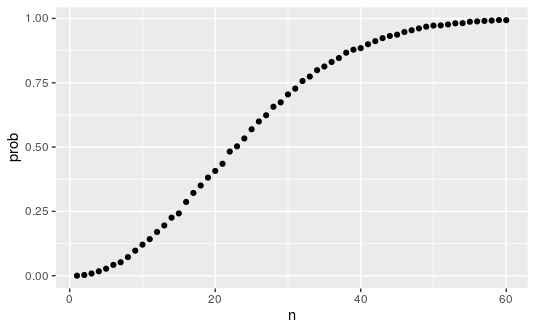

```r
library(tidyverse)
prob <- sapply(n, compute_prob)
qplot(n, prob)
```

Let’s compute the exact probabilities.

To make the math simpler, instead of computing the probability of it happening, we will compute the probability of it not happening. For this, we use the multiplication rule.

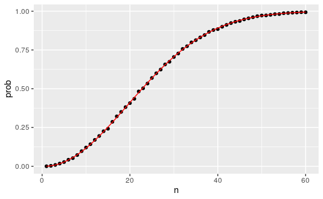

```r
exact_prob <- function(n){
  prob_unique <- seq(365,365-n+1)/365
  1 - prod( prob_unique)
}
eprob <- sapply(n, exact_prob)
qplot(n, prob) + geom_line(aes(n, eprob), col = "red")
```

## 13.8 Infinity in practice

In reality we cannot repeat experiments over and over forever. The larger the number of experiments, the more accurate the estimate becomes. But in practice, we won’t know what the answer is, so we won’t know if our Monte Carlo estimate is accurate. How big do we need ‘B’ to be?

One practical approach we will describe here is to check for the stability of the estimate.

birthday problem for 25 ppl:

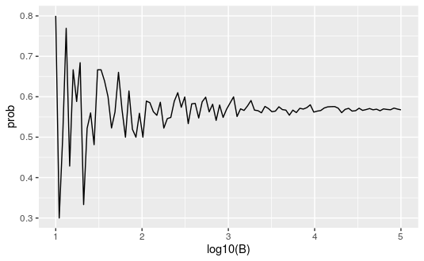

```r
B <- 10^seq(1, 5, len = 100)
compute_prob <- function(B, n=25){
  same_day <- replicate(B, same_birthday(n))
  mean(same_day)
}
prob <- sapply(B, compute_prob)
qplot(log10(B), prob, geom = "line")
```

We can see that values start to stabilize around 1000.

## 13.9 Exercises

1. One ball will be drawn at random from a box containing: 3 cyan balls, 5 magenta balls, and 7 yellow balls. What is the probability that the ball will be cyan?

**1/5**

2. What is the probability that the ball will not be cyan?

**4/5**

3. Instead of taking just one draw, consider taking two draws. You take the second draw without returning the first draw to the box. We call this sampling without replacement. What is the probability that the first draw is cyan and that the second draw is not cyan?

**1/5 x 12/14 = 6/35**

4. Now repeat the experiment, but this time, after taking the first draw and recording the color, return it to the box and shake the box. We call this sampling with replacement. What is the probability that the first draw is cyan and that the second draw is not cyan?

**1/5 x 4/5 = 4/25**

5. Two events A and B are independent if Pr(A and B)=Pr(A)Pr(B). Under which conditions are the draws independent?

A. You don’t replace the draw. **B. You replace the draw.** C. Neither D. Both

6. Say you’ve drawn 5 balls from the box, with replacement, and all have been yellow. What is the probability that the next one is yellow?

**7/15**

7. If you roll a 6-sided die six times, what is the probability of not seeing a 6?

**(5/6)^6**

8. Two teams, say the Celtics and the Cavs, are playing a seven game series. The Cavs are a better team and have a 60% chance of winning each game. What is the probability that the Celtics win at least one game?

**1-(3/5)^4**

9. Create a Monte Carlo simulation to confirm your answer to the previous problem. Use B <- 10000 simulations. Hint: use the following code to generate the results of the first four games:

```r
celtic_wins <- sample(c(0,1), 4, replace = TRUE, prob = c(0.6, 0.4))
```

The Celtics must win one of these 4 games.

```r
B <- 10000
wins <- replicate(B, {
  celtic_wins <- sample(c(0,1), 4, replace = TRUE, prob = c(0.6, 0.4))
  any(celtic_wins==1)
})
mean(wins)
```

```
[1] 0.8712
```

10. Two teams, say the Cavs and the Warriors, are playing a seven game championship series. The first to win four games, therefore, wins the series. The teams are equally good so they each have a 50-50 chance of winning each game. If the Cavs lose the first game, what is the probability that theycnl win the series?

```r
cavs <- expand.grid(rep(list(0:1), 6))
cavswin <- rowSums(cavs)>=4
mean(cavswin)
```

```
[1] 0.34375
```

11. Confirm the results of the previous question with a Monte Carlo simulation.

```r
B <- 10000
cavswin <- replicate(B, {
  cavs <- sample(c(0,1), 6, replace = TRUE)
  sum(cavs)>=4
})
mean(cavswin)
```

```
[1] 0.3445
```

12. Two teams, A and B, are playing a seven game series. Team A is better than team B and has a p>0.5 chance of winning each game. Given a value p, the probability of winning the series for the underdog team B can be computed with the following function based on a Monte Carlo simulation:

```r
prob_win <- function(p){
  B <- 10000
  result <- replicate(B, {
    b_win <- sample(c(1,0), 7, replace = TRUE, prob = c(1-p, p))
    sum(b_win)>=4
  })
  mean(result)
}
```

Use the function sapply to compute the probability, call it Pr, of winning for p <- seq(0.5, 0.95, 0.025). Then plot the result.

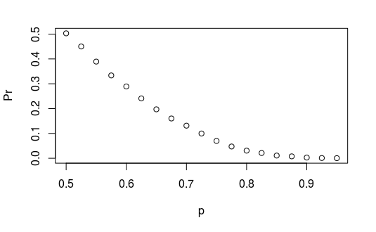

```r
p <- seq(0.5, 0.95, 0.025)
Pr <- sapply(p, prob_win)
plot(p, Pr)
```

13. Repeat the exercise above, but now keep the probability fixed at p <- 0.75 and compute the probability for different series lengths: best of 1 game, 3 games, 5 games,… Specifically, N <- seq(1, 25, 2). Hint: use this function:

```r
prob_win <- function(N, p=0.75){
  B <- 10000
  result <- replicate(B, {
    b_win <- sample(c(1,0), N, replace = TRUE, prob = c(1-p, p))
    sum(b_win)>=(N+1)/2
  })
  mean(result)
}
```

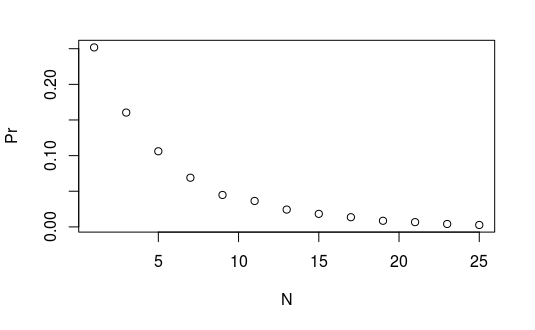

```r
N <- seq(1,25,2)
Pr <- sapply(N, prob_win)
plot(N, Pr)
```